# Assignment-1

### 6. Characterize the population group who work in the private sector and who have an education level of greater than a bachelor's degree (i.e., education-num values of 13 or more). You may consider first creating a separate dataframe consisting of this subset of the data. Then provide an analysis of the key chracteristics of this population group based on the statistics and data distributions of other attributes.

```python
private_bachelors = adult[ (adult["workclass"] == "Private") & (adult["education-num"] >= 13) ]
private_bachelors
```

|  | age | workclass | education-num | marital-status | occupation | relationship | race | sex | hours-per-week | income |
| --- | --- | --- | --- | --- | --- | --- | --- | --- | --- | --- |
| 9 | 45.0 | Private | 13 | Divorced | Exec-managerial | Own-child | White | Male | 40 | <=50K |
| 19 | 24.0 | Private | 13 | Married | Tech-support | Husband | White | Male | 50 | <=50K |
| 24 | 44.0 | Private | 14 | Divorced | Exec-managerial | Unmarried | White | Female | 40 | <=50K |
| 29 | 47.0 | Private | 15 | Married | Prof-specialty | Wife | White | Female | 60 | >50K |
| 37 | 30.0 | Private | 13 | Married | Sales | Husband | White | Male | 40 | <=50K |
| ... | ... | ... | ... | ... | ... | ... | ... | ... | ... | ... |
| 31728 | 43.0 | Private | 14 | Married | Prof-specialty | Husband | White | Male | 55 | <=50K |
| 31733 | 26.0 | Private | 13 | Never-married | Prof-specialty | Own-child | White | Female | 40 | <=50K |
| 31734 | 46.0 | Private | 13 | Never-married | Other-service | Not-in-family | White | Male | 40 | <=50K |
| 31736 | 50.0 | Private | 14 | Divorced | Prof-specialty | Not-in-family | White | Female | 35 | <=50K |
| 31738 | 23.0 | Private | 13 | Never-married | Sales | Not-in-family | White | Male | 48 | <=50K |

4611 rows × 10 columns

```python
# statistical findings
private_bachelors.describe()
```

|  | age | education-num | hours-per-week |
| --- | --- | --- | --- |
| count | 4611.000000 | 4611.000000 | 4611.000000 |
| mean | 38.801740 | 13.391021 | 43.560399 |
| std | 11.511458 | 0.745775 | 11.156838 |
| min | 19.000000 | 13.000000 | 2.000000 |
| 25% | 30.000000 | 13.000000 | 40.000000 |
| 50% | 38.000000 | 13.000000 | 40.000000 |
| 75% | 46.000000 | 14.000000 | 50.000000 |
| max | 90.000000 | 16.000000 | 99.000000 |

The mean age is still the same of the original data.

The mean education level has changed from 10 to 13, which should have been the case because we have filtered the group of having a bachelors' degree or more.

Average working hours per week has jumped from 40 to 43, which could be linked to private sector jobs and high educated individuals.

```python
# function to visualize all parameters as per its data type
def visualize_attributes(df):
 for col in df.columns:
    plt.figure(figsize=(6, 4))
    if df[col].dtype in ['int64', 'float64']:
        df[col].plot(kind='hist')
        plt.title(f'Histogram of {col}')
    else: # Assuming categorical
        df[col].value_counts().plot(kind='bar')
        plt.title(f'Bar Chart of {col}')
    plt.xlabel(col)
    plt.ylabel('Count' if df[col].dtype == 'object' else 'Frequency')
    plt.tight_layout()
    plt.show()
```

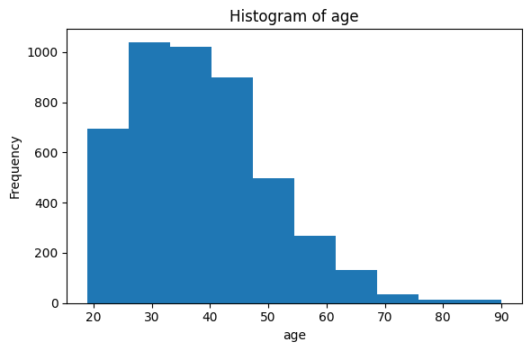

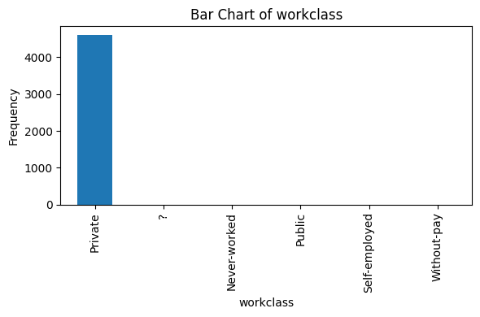

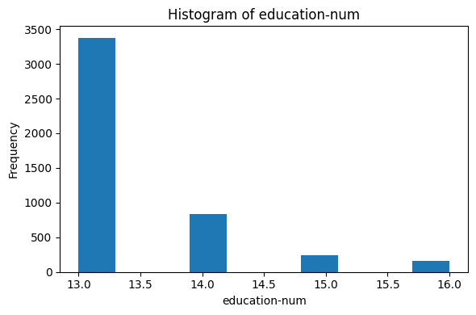

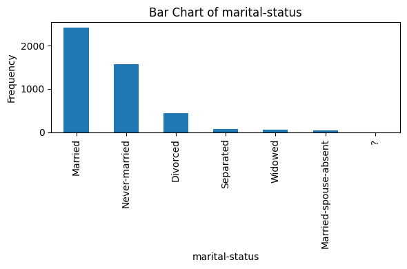

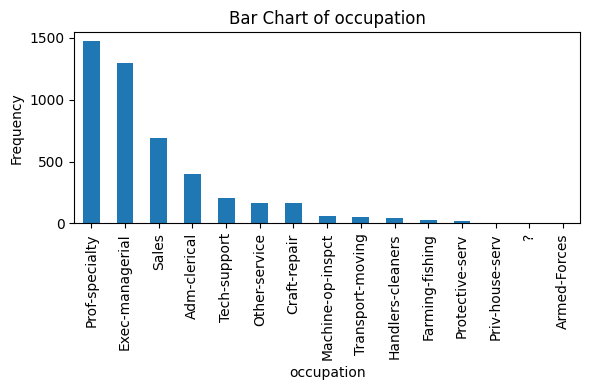

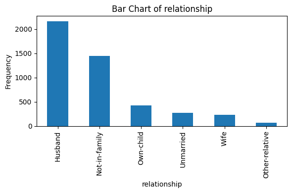

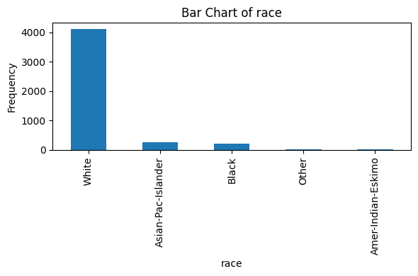

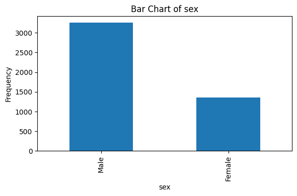

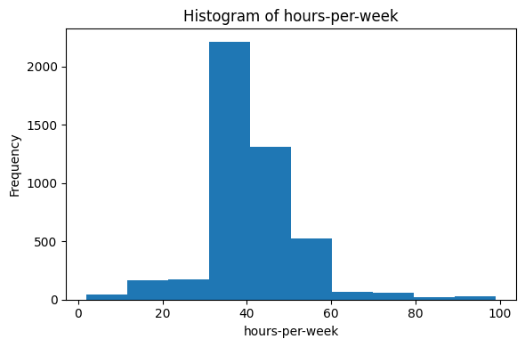

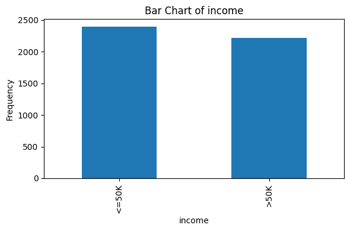

```python
visualize_attributes(private_bachelors)
```

The workclass distribution makes sense because we have kept only the private sector employees.

Likewise, for education level, which is, 13 and above.

The majority of people are married and then next we see are ones that never got married. Few are divorced. There are small percentages of separated or widowed or with spouses absent.

With these filters, the most popular occupation we find are 'Prof-speciality', 'Exec-manageiral', 'Sales', 'Adm-clerical'. These can be linked with roles requiring high levels of education. Then the less popular are 'Tech-support', 'Other-service' and 'craft-repair'. These also require education but may be not high or may be it is not chosen by most of the people. None are seen in armed-forces.

A higher majority of people in this section are having a family of their own. And few with a child of their own.

Husbands are more seen with this seggregation. This also comes from the observation that there are more males and females in this filtering.

White race is the majority.

The class imbalance between income group has now vanished. Now, only a very small difference is seen among two income groups, with still less than 50k a month more than the other.

### 7. Compare and contrast the characteristics of the low-income and high-income categories across the different attributes. As in the previous problem you may consider first creating separate subsets of the data based on these income categories and then characterizing each subset by observing summary statistics for each group across different variables. Discuss your observations focusing specifically on unique characteristics that seem to distinguish between the two groups. You may use charts or plots for visualizing the differences in your analysis to support your observations. [Note: the discussion of your observations about the key characteristics will be a significant part of the score for this problem.]

```python
# splitting the data
low_income = adult[ adult["income"] == '<=50K' ]
high_income = adult[ adult["income"] == '>50K' ]
```

```python
# comparing numerical attributes
low_income.describe()
```

|  | age | education-num | hours-per-week |
| --- | --- | --- | --- |
| count | 22102.000000 | 22102.000000 | 22102.000000 |
| mean | 36.591378 | 9.628359 | 39.343860 |
| std | 13.453790 | 2.410024 | 11.935438 |
| min | 17.000000 | 1.000000 | 1.000000 |
| 25% | 26.000000 | 9.000000 | 38.000000 |
| 50% | 34.000000 | 9.000000 | 40.000000 |
| 75% | 45.000000 | 10.000000 | 40.000000 |
| max | 90.000000 | 16.000000 | 99.000000 |

```python
high_income.describe()
```

|  | age | education-num | hours-per-week |
| --- | --- | --- | --- |
| count | 7312.000000 | 7312.000000 | 7312.000000 |
| mean | 43.971725 | 11.607358 | 45.714032 |
| std | 10.280205 | 2.365453 | 10.728396 |
| min | 19.000000 | 2.000000 | 1.000000 |
| 25% | 36.000000 | 10.000000 | 40.000000 |
| 50% | 43.000000 | 12.000000 | 40.000000 |
| 75% | 51.000000 | 13.000000 | 50.000000 |
| max | 90.000000 | 16.000000 | 99.000000 |

For low income groups, the mean age is 36, while for higher groups it 43. It can be understood that this might be due to the difference in experience. With age, experience increases and hence their income.

The average education level for low income group is 9 and for the high income group it is 11. The difference in income may also be because of the education level. People who are more qualified are earning more.

The average working hours per week for low income group is 39, which is close to standard 40 hrs a week. However, the people in high income group have an average of 45 hours per week. This could be the case that the people in higher income are employed in sectors that require more of their hours.

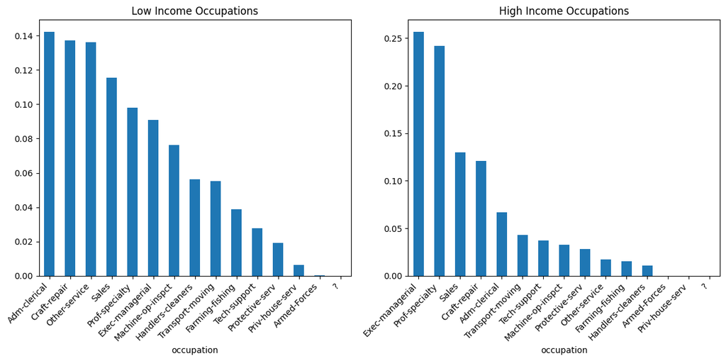

```python
#Comparing Occupation
plt.figure(figsize=(12, 6))

plt.subplot(1, 2, 1)
low_income['occupation'].value_counts(normalize=True).plot(kind='bar', title='Low Income Occupations')
plt.xticks(rotation=45, ha='right')

plt.subplot(1, 2, 2)
high_income['occupation'].value_counts(normalize=True).plot(kind='bar', title='High Income Occupations')
plt.xticks(rotation=45, ha='right')

plt.tight_layout()
plt.show()
```

Here, we can understand the choice of occupation in the two income groups.

There are common occupations between the two groups, but the proportion of people is different.

In low-income group, 'Adm-clerical' is the most popular one and 'Exec-managerial' for high income groups.

Nearly, same proportion are engaged in 'Tech-support'.

None of them are seen in 'armed-foces'.

'Priv-house-serv' is seen only low income group with a very small percentage of people.

The low income groups seems to have multiple popular groups while high income tend to prefer two occuaption a lot.

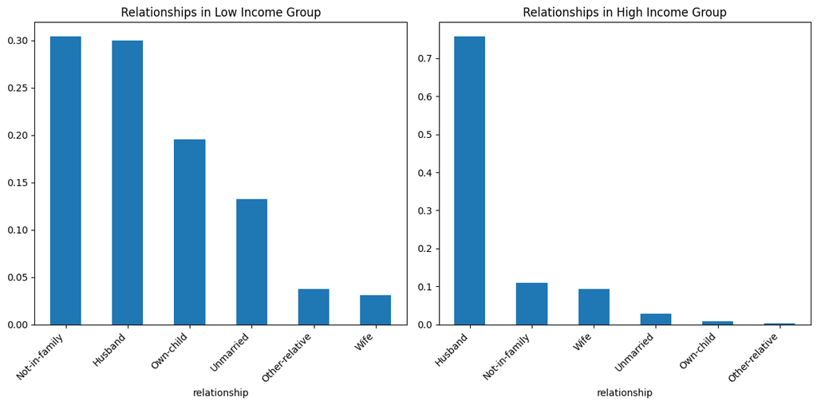

```python
#Comparing Relationship
plt.figure(figsize=(12, 6))

plt.subplot(1, 2, 1)
low_income['relationship'].value_counts(normalize=True).plot(kind='bar', title='Relationships in Low Income Group')
plt.xticks(rotation=45, ha='right')

plt.subplot(1, 2, 2)
high_income['relationship'].value_counts(normalize=True).plot(kind='bar', title='Relationships in High Income Group')
plt.xticks(rotation=45, ha='right')

plt.tight_layout()
plt.show()
```

In comparing the relationship of people in two income groups, it seems that people in low income group prefer to not engage in family and also roughly same percentage are married.

Unmarried people are seen more in low income group.

People in low income group are observed with a child of their own.

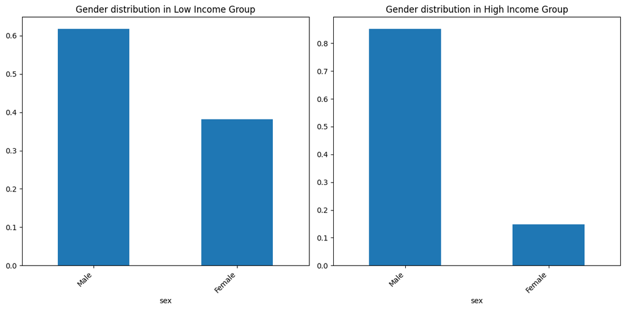

```python
#Comparing Gender
plt.figure(figsize=(12, 6))

plt.subplot(1, 2, 1)
low_income['sex'].value_counts(normalize=True).plot(kind='bar', title='Gender distribution in Low Income Group')
plt.xticks(rotation=45, ha='right')

plt.subplot(1, 2, 2)
high_income['sex'].value_counts(normalize=True).plot(kind='bar', title='Gender distribution in High Income Group')
plt.xticks(rotation=45, ha='right')

plt.tight_layout()
plt.show()
```

In both the income groups, male gender dominates the population.

In low income group, female are seen more than the high income group.

### 8. Convert the data into the standard spreadsheet format. Note that this requires converting each categorical attribute into multiple binary ("dummy") attributes (one for each values of the categorical attribute) and assigning binary values corresponding to the presence or not presence of the attribute value in the original record). The numeric attributes should remain unchanged. Save this data in a new dataframe and show the top 10 rows in the new dataframe. Also save this new table into a local file called adult_numeric.csv.

```python
# converting data to spreadsheet format
adult_spreadsheet = pd.get_dummies(adult, dtype=int)

# top 10 rows of new data frame
adult_spreadsheet.head(10)
```

|  | age | education-num | hours-per-week | workclass_? | workclass_Never-worked | workclass_Private | workclass_Public | workclass_Self-employed | workclass_Without-pay | marital-status_? | ... | relationship_Wife | race_Amer-Indian-Eskimo | race_Asian-Pac-Islander | race_Black | race_Other | race_White | sex_Female | sex_Male | income_<=50K | income_>50K |
| --- | --- | --- | --- | --- | --- | --- | --- | --- | --- | --- | --- | --- | --- | --- | --- | --- | --- | --- | --- | --- | --- |
| 0 | 38.568721 | 7 | 40 | 0 | 0 | 1 | 0 | 0 | 0 | 0 | ... | 0 | 0 | 0 | 0 | 0 | 1 | 0 | 1 | 1 | 0 |
| 1 | 59.000000 | 9 | 40 | 0 | 0 | 1 | 0 | 0 | 0 | 0 | ... | 0 | 0 | 0 | 0 | 0 | 1 | 1 | 0 | 1 | 0 |
| 2 | 56.000000 | 13 | 40 | 0 | 0 | 0 | 1 | 0 | 0 | 0 | ... | 0 | 0 | 0 | 0 | 0 | 1 | 0 | 1 | 0 | 1 |
| 3 | 19.000000 | 9 | 40 | 0 | 0 | 1 | 0 | 0 | 0 | 0 | ... | 0 | 0 | 0 | 0 | 0 | 1 | 0 | 1 | 1 | 0 |
| 5 | 39.000000 | 9 | 80 | 0 | 0 | 1 | 0 | 0 | 0 | 0 | ... | 0 | 0 | 0 | 0 | 0 | 1 | 0 | 1 | 1 | 0 |
| 6 | 49.000000 | 9 | 40 | 0 | 0 | 1 | 0 | 0 | 0 | 0 | ... | 0 | 0 | 0 | 0 | 0 | 1 | 0 | 1 | 1 | 0 |
| 7 | 23.000000 | 12 | 52 | 0 | 0 | 0 | 1 | 0 | 0 | 0 | ... | 0 | 0 | 0 | 0 | 0 | 1 | 0 | 1 | 1 | 0 |
| 8 | 20.000000 | 10 | 44 | 0 | 0 | 1 | 0 | 0 | 0 | 0 | ... | 0 | 0 | 0 | 1 | 0 | 0 | 0 | 1 | 1 | 0 |
| 9 | 45.000000 | 13 | 40 | 0 | 0 | 1 | 0 | 0 | 0 | 0 | ... | 0 | 0 | 0 | 0 | 0 | 1 | 0 | 1 | 1 | 0 |
| 10 | 30.000000 | 10 | 40 | 0 | 0 | 0 | 1 | 0 | 0 | 0 | ... | 0 | 0 | 0 | 0 | 0 | 1 | 0 | 1 | 1 | 0 |

10 rows × 46 columns

```python
# saving the data frame in a new local .csv file
adult_spreadsheet.to_csv('adult_numeric.csv', index=False)
```

### 9. Using the numeric data set with the dummy variables (of the previous part), perform basic correlation analysis among the attributes. You need to construct a complete Correlation Matrix (with rows and columns corresponding to each variable). [Hint: you can create the correlation matrix by using the corr() function in Pandas or corrcoef function in NumPy]. Next, using your correlation matrix, display in decreasing order of correlations, all attributes and their correlations to hours-per-week. Repeat this step to display correlations with the attribute income_<=50K. For each of these create a chart visualizing the relative correlations (see this example for correlations with age). Briefly discuss your general observations about this sample of adult population based on this correlation analysis.

```python
# correlation analysis
adult_spreadsheet.corr()
```

|  | age | education-num | hours-per-week | workclass_? | workclass_Never-worked | workclass_Private | workclass_Public | workclass_Self-employed | workclass_Without-pay | marital-status_? | ... | relationship_Wife | race_Amer-Indian-Eskimo | race_Asian-Pac-Islander | race_Black | race_Other | race_White | sex_Female | sex_Male | income_<=50K | income_>50K |
| --- | --- | --- | --- | --- | --- | --- | --- | --- | --- | --- | --- | --- | --- | --- | --- | --- | --- | --- | --- | --- | --- |
| age | 1.000000 | 0.045604 | 0.102822 | NaN | NaN | -0.209536 | 0.085219 | 0.191724 | 0.013237 | NaN | ... | 0.024731 | -0.012086 | -0.005949 | -0.013659 | -0.031494 | 0.025639 | -0.082624 | 0.082624 | -0.242902 | 0.242902 |
| education-num | 0.045604 | 1.000000 | 0.153353 | NaN | NaN | -0.165484 | 0.159940 | 0.052713 | -0.009250 | NaN | ... | 0.034407 | -0.027589 | 0.060959 | -0.071758 | -0.048733 | 0.050259 | -0.006784 | 0.006784 | -0.335831 | 0.335831 |
| hours-per-week | 0.102822 | 0.153353 | 1.000000 | NaN | NaN | -0.096813 | -0.014957 | 0.148411 | -0.012172 | NaN | ... | -0.060536 | -0.003296 | -0.005819 | -0.060666 | -0.006347 | 0.056183 | -0.229970 | 0.229970 | -0.230049 | 0.230049 |
| workclass_? | NaN | NaN | NaN | NaN | NaN | NaN | NaN | NaN | NaN | NaN | ... | NaN | NaN | NaN | NaN | NaN | NaN | NaN | NaN | NaN | NaN |
| workclass_Never-worked | NaN | NaN | NaN | NaN | NaN | NaN | NaN | NaN | NaN | NaN | ... | NaN | NaN | NaN | NaN | NaN | NaN | NaN | NaN | NaN | NaN |
| workclass_Private | -0.209536 | -0.165484 | -0.096813 | NaN | NaN | 1.000000 | -0.684288 | -0.617202 | -0.035349 | NaN | ... | -0.019431 | -0.018181 | -0.002655 | 0.004174 | 0.029137 | -0.004426 | 0.067683 | -0.067683 | 0.116162 | -0.116162 |
| workclass_Public | 0.085219 | 0.159940 | -0.014957 | NaN | NaN | -0.684288 | 1.000000 | -0.149451 | -0.008559 | NaN | ... | 0.026456 | 0.030280 | 0.002816 | 0.067389 | -0.018977 | -0.061539 | 0.044327 | -0.044327 | -0.054661 | 0.054661 |
| workclass_Self-employed | 0.191724 | 0.052713 | 0.148411 | NaN | NaN | -0.617202 | -0.149451 | 1.000000 | -0.007720 | NaN | ... | -0.002861 | -0.007857 | 0.000185 | -0.078325 | -0.018968 | 0.072485 | -0.139713 | 0.139713 | -0.099545 | 0.099545 |
| workclass_Without-pay | 0.013237 | -0.009250 | -0.012172 | NaN | NaN | -0.035349 | -0.008559 | -0.007720 | 1.000000 | NaN | ... | 0.010704 | -0.002061 | 0.005854 | -0.001179 | -0.001846 | -0.000835 | -0.000736 | 0.000736 | 0.012095 | -0.012095 |
| marital-status_? | NaN | NaN | NaN | NaN | NaN | NaN | NaN | NaN | NaN | NaN | ... | NaN | NaN | NaN | NaN | NaN | NaN | NaN | NaN | NaN | NaN |
| marital-status_Divorced | 0.135797 | -0.006672 | 0.020145 | NaN | NaN | -0.004081 | 0.036534 | -0.033339 | -0.008472 | NaN | ... | -0.089052 | 0.015045 | -0.032321 | 0.020257 | -0.012860 | -0.002146 | 0.236958 | -0.236958 | 0.131893 | -0.131893 |
| marital-status_Married | 0.308554 | 0.081700 | 0.223220 | NaN | NaN | -0.128131 | 0.010304 | 0.162692 | 0.003025 | NaN | ... | 0.236278 | -0.018718 | 0.009070 | -0.125548 | -0.011735 | 0.108924 | -0.436291 | 0.436291 | -0.446475 | 0.446475 |
| marital-status_Married-spouse-absent | 0.016181 | -0.039981 | -0.008936 | NaN | NaN | 0.007807 | -0.001923 | -0.009331 | 0.012371 | NaN | ... | -0.024603 | 0.014562 | 0.040659 | 0.019611 | 0.039912 | -0.050404 | 0.045148 | -0.045148 | 0.043278 | -0.043278 |
| marital-status_Never-married | -0.523750 | -0.031970 | -0.212414 | NaN | NaN | 0.135920 | -0.042208 | -0.138986 | -0.000702 | NaN | ... | -0.152778 | 0.003347 | 0.010170 | 0.070116 | 0.008554 | -0.066795 | 0.175824 | -0.175824 | 0.320554 | -0.320554 |
| marital-status_Separated | 0.012073 | -0.051977 | -0.018260 | NaN | NaN | 0.021513 | -0.005589 | -0.022940 | -0.003751 | NaN | ... | -0.039425 | 0.000741 | -0.011495 | 0.101089 | 0.013683 | -0.082707 | 0.109282 | -0.109282 | 0.073019 | -0.073019 |
| marital-status_Widowed | 0.246273 | -0.062089 | -0.091190 | NaN | NaN | -0.017284 | 0.019131 | 0.002409 | 0.006412 | NaN | ... | -0.037004 | 0.005086 | -0.003448 | 0.019556 | -0.002719 | -0.015437 | 0.180690 | -0.180690 | 0.059589 | -0.059589 |
| occupation_? | NaN | NaN | NaN | NaN | NaN | NaN | NaN | NaN | NaN | NaN | ... | NaN | NaN | NaN | NaN | NaN | NaN | NaN | NaN | NaN | NaN |
| occupation_Adm-clerical | -0.041835 | -0.002014 | -0.104430 | NaN | NaN | 0.012121 | 0.089453 | -0.113135 | 0.001948 | NaN | ... | 0.084855 | -0.003775 | 0.015407 | 0.047184 | -0.006834 | -0.044289 | 0.281836 | -0.281836 | 0.099056 | -0.099056 |
| occupation_Armed-Forces | -0.009170 | 0.000840 | 0.005268 | NaN | NaN | -0.027727 | 0.040520 | -0.006056 | -0.000347 | NaN | ... | -0.003646 | 0.019616 | -0.002885 | 0.001803 | -0.001448 | -0.005224 | -0.011421 | 0.011421 | 0.004717 | -0.004717 |
| occupation_Craft-repair | 0.015761 | -0.154355 | 0.042495 | NaN | NaN | 0.037641 | -0.087111 | 0.043127 | -0.003484 | NaN | ... | -0.075263 | 0.005866 | -0.021408 | -0.048632 | -0.008013 | 0.051579 | -0.226795 | 0.226795 | 0.021115 | -0.021115 |
| occupation_Exec-managerial | 0.111470 | 0.202187 | 0.133789 | NaN | NaN | -0.068071 | 0.003714 | 0.088968 | -0.008202 | NaN | ... | 0.022921 | -0.008246 | 0.001612 | -0.045618 | -0.021566 | 0.045148 | -0.031684 | 0.031684 | -0.211556 | 0.211556 |
| occupation_Farming-fishing | 0.040889 | -0.108905 | 0.093603 | NaN | NaN | -0.118402 | -0.047258 | 0.208520 | 0.050522 | NaN | ... | -0.028112 | 0.001541 | -0.014295 | -0.032929 | 0.007864 | 0.032170 | -0.102484 | 0.102484 | 0.056719 | -0.056719 |
| occupation_Handlers-cleaners | -0.104812 | -0.137517 | -0.057262 | NaN | NaN | 0.093812 | -0.052494 | -0.070955 | 0.003255 | NaN | ... | -0.035441 | 0.014264 | -0.016622 | 0.025387 | -0.000183 | -0.017085 | -0.094299 | 0.094299 | 0.094660 | -0.094660 |
| occupation_Machine-op-inspct | -0.015292 | -0.170755 | -0.004454 | NaN | NaN | 0.130986 | -0.092659 | -0.077943 | 0.000985 | NaN | ... | -0.007520 | -0.000419 | -0.005711 | 0.040138 | 0.038365 | -0.040347 | -0.028174 | 0.028174 | 0.076007 | -0.076007 |
| occupation_Other-service | -0.093003 | -0.181005 | -0.182726 | NaN | NaN | 0.071674 | -0.034665 | -0.059792 | -0.002025 | NaN | ... | 0.013009 | 0.002425 | 0.012912 | 0.093028 | 0.013911 | -0.088417 | 0.165067 | -0.165067 | 0.166623 | -0.166623 |
| occupation_Priv-house-serv | 0.019209 | -0.079492 | -0.047483 | NaN | NaN | 0.041578 | -0.028451 | -0.025662 | -0.001470 | NaN | ... | 0.003107 | -0.006852 | -0.000703 | 0.022980 | 0.010693 | -0.019675 | 0.092591 | -0.092591 | 0.039071 | -0.039071 |
| occupation_Prof-specialty | 0.060973 | 0.426611 | 0.048844 | NaN | NaN | -0.163009 | 0.193179 | 0.013412 | -0.008265 | NaN | ... | 0.053394 | -0.004595 | 0.030117 | -0.051148 | -0.002416 | 0.030014 | 0.037656 | -0.037656 | -0.182197 | 0.182197 |
| occupation_Protective-serv | 0.004328 | 0.004303 | 0.022294 | NaN | NaN | -0.151133 | 0.233141 | -0.046182 | -0.003103 | NaN | ... | -0.024801 | 0.004924 | -0.006393 | 0.029591 | 0.000551 | -0.023179 | -0.064971 | 0.064971 | -0.026759 | 0.026759 |
| occupation_Sales | -0.028791 | 0.025417 | -0.005656 | NaN | NaN | 0.057657 | -0.140627 | 0.073980 | -0.007730 | NaN | ... | -0.020480 | -0.007932 | -0.005529 | -0.031579 | -0.005769 | 0.032825 | 0.018646 | -0.018646 | -0.018810 | 0.018810 |
| occupation_Tech-support | -0.018535 | 0.057705 | -0.022253 | NaN | NaN | 0.020286 | 0.018741 | -0.047536 | -0.003708 | NaN | ... | 0.004421 | -0.009097 | 0.016018 | -0.012094 | -0.008636 | 0.007012 | 0.018076 | -0.018076 | -0.024149 | 0.024149 |
| occupation_Transport-moving | 0.033673 | -0.125159 | 0.073235 | NaN | NaN | 0.028005 | -0.017861 | -0.018908 | 0.002351 | NaN | ... | -0.039466 | 0.014838 | -0.022964 | 0.010097 | 0.002250 | -0.001946 | -0.134516 | 0.134516 | 0.023662 | -0.023662 |
| relationship_Husband | 0.307662 | 0.073694 | 0.253591 | NaN | NaN | -0.123138 | 0.000613 | 0.166859 | -0.004499 | NaN | ... | -0.185407 | -0.022506 | -0.003491 | -0.125996 | -0.016589 | 0.117719 | -0.580682 | 0.580682 | -0.400979 | 0.400979 |
| relationship_Not-in-family | -0.024606 | 0.057217 | 0.007976 | NaN | NaN | 0.032594 | 0.013283 | -0.057800 | -0.012320 | NaN | ... | -0.129500 | -0.000447 | -0.019797 | 0.003554 | -0.001343 | 0.007165 | 0.170373 | -0.170373 | 0.192545 | -0.192545 |
| relationship_Other-relative | -0.069649 | -0.091781 | -0.051520 | NaN | NaN | 0.042079 | -0.025262 | -0.029642 | -0.003658 | NaN | ... | -0.038450 | 0.005755 | 0.047882 | 0.042560 | 0.035568 | -0.069606 | 0.040443 | -0.040443 | 0.085151 | -0.085151 |
| relationship_Own-child | -0.420723 | -0.097632 | -0.263700 | NaN | NaN | 0.110745 | -0.053834 | -0.093201 | 0.013942 | NaN | ... | -0.092377 | 0.001341 | 0.006859 | 0.021774 | -0.004890 | -0.020742 | 0.103622 | -0.103622 | 0.227129 | -0.227129 |
| relationship_Unmarried | 0.050152 | -0.059127 | -0.042300 | NaN | NaN | 0.012957 | 0.038045 | -0.058867 | 0.003207 | NaN | ... | -0.076409 | 0.028470 | -0.007911 | 0.146655 | 0.013876 | -0.130438 | 0.326141 | -0.326141 | 0.145855 | -0.145855 |
| relationship_Wife | 0.024731 | 0.034407 | -0.060536 | NaN | NaN | -0.019431 | 0.026456 | -0.002861 | 0.010704 | NaN | ... | 1.000000 | 0.004916 | 0.010779 | 0.001269 | 0.000963 | -0.007951 | 0.318867 | -0.318867 | -0.127078 | 0.127078 |
| race_Amer-Indian-Eskimo | -0.012086 | -0.027589 | -0.003296 | NaN | NaN | -0.018181 | 0.030280 | -0.007857 | -0.002061 | NaN | ... | 0.004916 | 1.000000 | -0.017146 | -0.031433 | -0.008607 | -0.242906 | 0.011418 | -0.011418 | 0.029654 | -0.029654 |
| race_Asian-Pac-Islander | -0.005949 | 0.060959 | -0.005819 | NaN | NaN | -0.002655 | 0.002816 | 0.000185 | 0.005854 | NaN | ... | 0.010779 | -0.017146 | 1.000000 | -0.056076 | -0.015355 | -0.433344 | 0.000896 | -0.000896 | -0.010189 | 0.010189 |
| race_Black | -0.013659 | -0.071758 | -0.060666 | NaN | NaN | 0.004174 | 0.067389 | -0.078325 | -0.001179 | NaN | ... | 0.001269 | -0.031433 | -0.056076 | 1.000000 | -0.028151 | -0.794449 | 0.118031 | -0.118031 | 0.087020 | -0.087020 |
| race_Other | -0.031494 | -0.048733 | -0.006347 | NaN | NaN | 0.029137 | -0.018977 | -0.018968 | -0.001846 | NaN | ... | 0.000963 | -0.008607 | -0.015355 | -0.028151 | 1.000000 | -0.217541 | 0.009243 | -0.009243 | 0.031539 | -0.031539 |
| race_White | 0.025639 | 0.050259 | 0.056183 | NaN | NaN | -0.004426 | -0.061539 | 0.072485 | -0.000835 | NaN | ... | -0.007951 | -0.242906 | -0.433344 | -0.794449 | -0.217541 | 1.000000 | -0.104831 | 0.104831 | -0.084131 | 0.084131 |
| sex_Female | -0.082624 | -0.006784 | -0.229970 | NaN | NaN | 0.067683 | 0.044327 | -0.139713 | -0.000736 | NaN | ... | 0.318867 | 0.011418 | 0.000896 | 0.118031 | 0.009243 | -0.104831 | 1.000000 | -1.000000 | 0.216235 | -0.216235 |
| sex_Male | 0.082624 | 0.006784 | 0.229970 | NaN | NaN | -0.067683 | -0.044327 | 0.139713 | 0.000736 | NaN | ... | -0.318867 | -0.011418 | -0.000896 | -0.118031 | -0.009243 | 0.104831 | -1.000000 | 1.000000 | -0.216235 | 0.216235 |
| income_<=50K | -0.242902 | -0.335831 | -0.230049 | NaN | NaN | 0.116162 | -0.054661 | -0.099545 | 0.012095 | NaN | ... | -0.127078 | 0.029654 | -0.010189 | 0.087020 | 0.031539 | -0.084131 | 0.216235 | -0.216235 | 1.000000 | -1.000000 |
| income_>50K | 0.242902 | 0.335831 | 0.230049 | NaN | NaN | -0.116162 | 0.054661 | 0.099545 | -0.012095 | NaN | ... | 0.127078 | -0.029654 | 0.010189 | -0.087020 | -0.031539 | 0.084131 | -0.216235 | 0.216235 | -1.000000 | 1.000000 |

46 rows × 46 columns

```python
#correlation matrix
corr_matrix = adult_spreadsheet.corr()
```

```python
# correlation with hours-per-week
hours_corr = corr_matrix['hours-per-week'].sort_values(ascending=False)

# correlation with income<=50k
low_income_corr = corr_matrix['income_<=50K'].sort_values(ascending=False)
```

```python
hours_corr
```

```
hours-per-week                          1.000000
relationship_Husband                    0.253591
income_>50K                             0.230049
sex_Male                                0.229970
marital-status_Married                  0.223220
education-num                           0.153353
workclass_Self-employed                 0.148411
occupation_Exec-managerial              0.133789
age                                     0.102822
occupation_Farming-fishing              0.093603
occupation_Transport-moving             0.073235
race_White                              0.056183
occupation_Prof-specialty               0.048844
occupation_Craft-repair                 0.042495
occupation_Protective-serv              0.022294
marital-status_Divorced                 0.020145
relationship_Not-in-family              0.007976
occupation_Armed-Forces                 0.005268
race_Amer-Indian-Eskimo                -0.003296
occupation_Machine-op-inspct           -0.004454
occupation_Sales                       -0.005656
race_Asian-Pac-Islander                -0.005819
race_Other                             -0.006347
marital-status_Married-spouse-absent   -0.008936
workclass_Without-pay                  -0.012172
workclass_Public                       -0.014957
marital-status_Separated               -0.018260
occupation_Tech-support                -0.022253
relationship_Unmarried                 -0.042300
occupation_Priv-house-serv             -0.047483
relationship_Other-relative            -0.051520
occupation_Handlers-cleaners           -0.057262
relationship_Wife                      -0.060536
race_Black                             -0.060666
marital-status_Widowed                 -0.091190
workclass_Private                      -0.096813
occupation_Adm-clerical                -0.104430
occupation_Other-service               -0.182726
marital-status_Never-married           -0.212414
sex_Female                             -0.229970
income_<=50K                           -0.230049
relationship_Own-child                 -0.263700
workclass_?                                  NaN
workclass_Never-worked                       NaN
marital-status_?                             NaN
occupation_?                                 NaN
Name: hours-per-week, dtype: float64
```

```python
low_income_corr
```

```
income_<=50K                            1.000000
marital-status_Never-married            0.320554
relationship_Own-child                  0.227129
sex_Female                              0.216235
relationship_Not-in-family              0.192545
occupation_Other-service                0.166623
relationship_Unmarried                  0.145855
marital-status_Divorced                 0.131893
workclass_Private                       0.116162
occupation_Adm-clerical                 0.099056
occupation_Handlers-cleaners            0.094660
race_Black                              0.087020
relationship_Other-relative             0.085151
occupation_Machine-op-inspct            0.076007
marital-status_Separated                0.073019
marital-status_Widowed                  0.059589
occupation_Farming-fishing              0.056719
marital-status_Married-spouse-absent    0.043278
occupation_Priv-house-serv              0.039071
race_Other                              0.031539
race_Amer-Indian-Eskimo                 0.029654
occupation_Transport-moving             0.023662
occupation_Craft-repair                 0.021115
workclass_Without-pay                   0.012095
occupation_Armed-Forces                 0.004717
race_Asian-Pac-Islander                -0.010189
occupation_Sales                       -0.018810
occupation_Tech-support                -0.024149
occupation_Protective-serv             -0.026759
workclass_Public                       -0.054661
race_White                             -0.084131
workclass_Self-employed                -0.099545
relationship_Wife                      -0.127078
occupation_Prof-specialty              -0.182197
occupation_Exec-managerial             -0.211556
sex_Male                               -0.216235
hours-per-week                         -0.230049
age                                    -0.242902
education-num                          -0.335831
relationship_Husband                   -0.400979
marital-status_Married                 -0.446475
income_>50K                            -1.000000
workclass_?                                  NaN
workclass_Never-worked                       NaN
marital-status_?                             NaN
occupation_?                                 NaN
Name: income_<=50K, dtype: float64
```

```python
# funnction to plot the correlations
def plot_correlations(data,title):
    plt.figure(figsize=(8,4))
    data.plot(kind='bar')
    plt.title(title)
    plt.ylabel('Correlation values')
    plt.axhline(0, color='black', linewidth=0.8)
    plt.show()
```

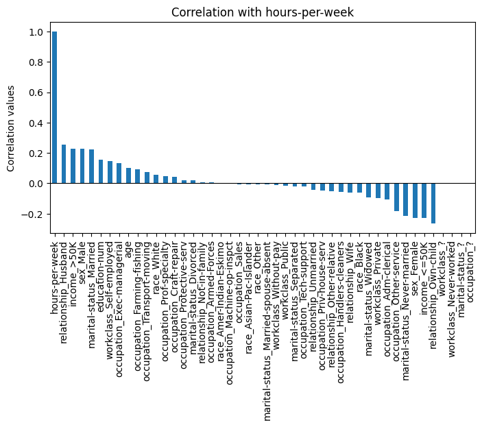

```python
# display the charts
plot_correlations(hours_corr, "Correlation with hours-per-week")
```

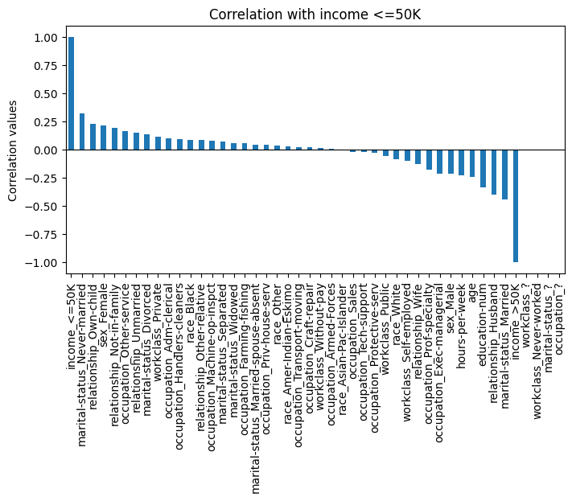

```python
plot_correlations(low_income_corr, "Correlation with income <=50K")
```

There is a high poistive correlation of 'income <50k' with 'nver-married', 'own-child', and occupation of 'other-service'. This shows that younger, single individuals and those in service industries are more likely to fall into this category.

A high negative correlation is seen of 'age' and 'education-num' with low income. This means that as age and education increases, the likelihood of being under 'low income group' decreases significantly.

### 10. Discretize the age attribute into 3 categories (corresponding to "young", "mid-age", and "old"). Do not change the original age attribute or add the discretized age to the table. Create a new dataframe with the numeric and the discretized age attributes as two columns and display the top 10 rows of the new dataframe.

```python
# creating age bins
age_bins = pd.qcut(adult.age, 3, labels=["young", "mid-age", "high"])
```

```python
# creating new data frame
age_comparison = pd.DataFrame({
    'age': adult['age'],
    'age_group': age_bins
})
```

```python
# display top 10 rows of new data frame
age_comparison.head(10)
```

|  | age | age_group |
| --- | --- | --- |
| 0 | 38.568721 | mid-age |
| 1 | 59.000000 | high |
| 2 | 56.000000 | high |
| 3 | 19.000000 | young |
| 5 | 39.000000 | mid-age |
| 6 | 49.000000 | high |
| 7 | 23.000000 | young |
| 8 | 20.000000 | young |
| 9 | 45.000000 | high |
| 10 | 30.000000 | young |

### 11. Use Min-Max Normalization to transform the values of the attribute hours-per-week the range 0.0-1.0 (without changing the original data). Next, perform zscore normalization (on the original data) to standardize the values of all numeric attributes (age, hours-per-week, education-num). The latter step should be performed on all three attributes at the same time instead of one-by-one (you may wish to first create a separate dataframe with only these attributes and perform the operation on the whole dataframe. Note: for this problem, you should write your own code to perform the normalization; do not use pre-existing functions such as scikit-learn's MinMaxScaler(). Finally, show the top 10 rows of the three versions of the hours-per-week attribute (original, normalized, and standardized) side-by-side in a new dataframe.

```python
# Min-Max Normalization for hours-per-week

# min hours value
min_hour = adult['hours-per-week'].min()

# max hours value
max_hour = adult['hours-per-week'].max()

normalized_hours = (adult['hours-per-week'] - min_hour) / (max_hour - min_hour)

normalized_hours.head(10)
```

```
0     0.397959
1     0.397959
2     0.397959
3     0.397959
5     0.806122
6     0.397959
7     0.520408
8     0.438776
9     0.397959
10    0.397959
Name: hours-per-week, dtype: float64
```

```python
# dataframe with only the numeric attributes
adult_numeric = adult[["age","hours-per-week","education-num"]]

# standardization
adult_standardized = (adult_numeric - adult_numeric.mean()) / adult_numeric.std()

adult_standardized.head()
```

|  | age | hours-per-week | education-num |
| --- | --- | --- | --- |
| 0 | 0.010864 | -0.077492 | -1.225143 |
| 1 | 1.566697 | -0.077492 | -0.439875 |
| 2 | 1.338248 | -0.077492 | 1.130662 |
| 3 | -1.479285 | -0.077492 | -0.439875 |
| 5 | 0.043706 | 3.264787 | -0.439875 |

```python
# comparing the three varsions of hours-per-week
compare_hours = pd.DataFrame({
    'original hours': adult['hours-per-week'],
    'normalized hours': normalized_hours,
    'standardized hours': adult_standardized['hours-per-week']
})
```

```python
# viewing first 10 rows for comparison
compare_hours.head(10)
```

|  | original hours | normalized hours | standardized hours |
| --- | --- | --- | --- |
| 0 | 40 | 0.397959 | -0.077492 |
| 1 | 40 | 0.397959 | -0.077492 |
| 2 | 40 | 0.397959 | -0.077492 |
| 3 | 40 | 0.397959 | -0.077492 |
| 5 | 80 | 0.806122 | 3.264787 |
| 6 | 40 | 0.397959 | -0.077492 |
| 7 | 52 | 0.520408 | 0.925192 |
| 8 | 44 | 0.438776 | 0.256736 |
| 9 | 40 | 0.397959 | -0.077492 |
| 10 | 40 | 0.397959 | -0.077492 |